# SDM Workflow for COCA I

### Summarizing results: Projected changes across spatial scales from the large marine ecosystem to coastal communities

After making the projections, we can calculate changes in relative biomass for the different climate scenarios/ensemble statistic/time horizons for each location within the Northeast U.S. Large Marine Ecosystem. In COCOA I, we then summarized these changes across a few different scales: the large marine ecosystem, biophysical regions within the large marine ecosystem (Gulf of Maine vs. southern New England/Mid-Atlantic Bight), and then finally, coastal communities using vessel trip reports.

There’s some weirdness that arises here, especially related to trying to calculate and visualize projected changes as percentages. If we try to do the calculation of the percentage at each cell and then average these within a spatial area of interest, we run into issues with `-Inf` when the baseline biomass at the cell is 0. To get around this, during the COCA I project, we first calculated the average biomass within the spatial area for each period (e.g., baseline biomass and then the climate scenarios/ensemble statistic/time horizons projected biomass). Then we perform the percentage calculations based on those average values.

#### Summarizing differences across biophysical regions

First, let’s use an overlay function that can take in different shapefiles and then calculate the average biomass (or probability of presence) within that area. For now, we can use a shapefile that includes the Northeast U.S. LME, the Gulf of Maine, and then just the southern New England/Mid-Atlantic Bight area.

```r
# Regions of interest
nelme_sf<- st_read(paste(res_dat_path, "/Shapefiles/NELME_regions/NELME_sf.shp", sep = ""))
gom_sf<- st_read(paste(res_dat_path, "/Shapefiles/NELME_regions/GoM_sf.shp", sep = ""))
snemab_sf<- st_read(paste(res_dat_path, "/Shapefiles/NELME_regions/SNEandMAB_sf.shp", sep = ""))

# Visualize them quickly. Wrong! This takes forever, so commenting out for now.
# spat_area_plot<- ggplot() +
#   geom_sf(data = nelme_sf, fill = NA, color = "#1b9e77", lwd = 2) +
#   geom_sf(data = gom_sf, fill = NA, color = "#7570b3", lwd = 1.25) +
#   geom_sf(data = snemab_sf, fill = NA, color = "#d95f02", lwd = 1.25) +
#   geom_sf(data = land, fill = "#f6f6f6", color = "light gray") +
#   coord_sf(xlim, ylim, expand = FALSE) +
#   xlab("") +
#   ylab("") +
#   theme_bw()

# Now, the overlay func
shp_over_pts_func<- function(dat, shp_file){
  if(FALSE){
    dat<- mod_res$RCP45_2055_Mu_Biomass[[1]]
    shp_file<- nelme_sf
  }

  # Convert data frame to sf object
  dat_sf<- dat %>%
    st_as_sf(., coords = c("x", "y"), crs = 4326, remove = FALSE)

  # Calculate average with sf aggregate and then simplify things to just return the average value
  mean_out<- aggregate(dat_sf, shp_file, mean, na.rm = TRUE, join = st_intersects) %>%
    st_drop_geometry() %>%
    select(., Pred) %>%
    as.numeric()
  return(mean_out)
}
```

Now, map that function to our `mod_res` object to get the average projected biomass under different conditions within the NELME, GoM and SNE-MAB regions. Then, make a quick plot showing an example of the results.

```r
# Mapping it to our mod_res dataframe. Name explosion -- help!!!
mod_res<- mod_res %>%
  mutate(., "NELME_Baseline_Biomass" = map2_dbl(Proj_Baseline_Biomass, list(nelme_sf), shp_over_pts_func),
         "NELME_RCP45_2055_Biomass" = map2_dbl(RCP45_2055_Mu_Biomass, list(nelme_sf), shp_over_pts_func),
         "NELME_RCP85_2055_Biomass" = map2_dbl(RCP85_2055_Mu_Biomass, list(nelme_sf), shp_over_pts_func),
         "GoM_Baseline_Biomass" = map2_dbl(Proj_Baseline_Biomass, list(gom_sf), shp_over_pts_func),
         "GoM_RCP45_2055_Biomass" = map2_dbl(RCP45_2055_Mu_Biomass, list(gom_sf), shp_over_pts_func),
         "GoM_RCP85_2055_Biomass" = map2_dbl(RCP85_2055_Mu_Biomass, list(gom_sf), shp_over_pts_func),
         "SNEMAB_Baseline_Biomass" = map2_dbl(Proj_Baseline_Biomass, list(snemab_sf), shp_over_pts_func),
         "SNEMAB_RCP45_2055_Biomass" = map2_dbl(RCP45_2055_Mu_Biomass, list(snemab_sf), shp_over_pts_func),
         "SNEMAB_RCP85_2055_Biomass" = map2_dbl(RCP85_2055_Mu_Biomass, list(snemab_sf), shp_over_pts_func))

# Percentage changes
cols_keep<- c("COMNAME", "SEASON", "NELME", "GoM", "SNEMAB")
proj_perc_change<- mod_res %>%
  select(., matches(paste(cols_keep, collapse="|"))) %>%
  mutate(., "NELME_RCP45_2055_PercChange" = 100*((NELME_RCP45_2055_Biomass - NELME_Baseline_Biomass)/NELME_Baseline_Biomass),
         "NELME_RCP85_2055_PercChange" = 100*((NELME_RCP85_2055_Biomass - NELME_Baseline_Biomass)/NELME_Baseline_Biomass),
         "GoM_RCP45_2055_PercChange" = 100*((GoM_RCP45_2055_Biomass - GoM_Baseline_Biomass)/GoM_Baseline_Biomass),
         "GoM_RCP85_2055_PercChange" = 100*((GoM_RCP85_2055_Biomass - GoM_Baseline_Biomass)/GoM_Baseline_Biomass),
         "SNEMAB_RCP45_2055_PercChange" = 100*((SNEMAB_RCP45_2055_Biomass - SNEMAB_Baseline_Biomass)/SNEMAB_Baseline_Biomass),
         "SNEMAB_RCP85_2055_PercChange" = 100*((SNEMAB_RCP85_2055_Biomass - SNEMAB_Baseline_Biomass)/SNEMAB_Baseline_Biomass))

# Quick plot...
# First get to a long format, filter to only the projected changes, and then create a column that has "region"
proj_perc_long<- proj_perc_change %>%
  pivot_longer(., cols = NELME_Baseline_Biomass:SNEMAB_RCP85_2055_PercChange, names_to = "Variable", values_to = "Value") %>%
  filter(., grepl("PercChange", Variable)) %>%
  separate(., Variable, c("Region", "Variable"), extra = "merge", remove = TRUE)
proj_perc_long$Region<- factor(proj_perc_long$Region, levels = c("NELME", "GoM", "SNEMAB"))

perc_change_plot<- ggplot(data = proj_perc_long, aes(x = COMNAME, y = Value, fill = Region)) +
    geom_bar(stat = "identity", width = 0.6, position = position_dodge(width = 0.6)) +
    scale_fill_manual(name = "Region", values  = c("#1b9e77", "#7570b3", "#d95f02")) +
    ylab("Percent change in relative biomass") +
    xlab("Species") +
    geom_hline(yintercept = 0) +
    theme_bw() +
    theme(text = element_text(size = 12),
          strip.background = element_blank(),
          panel.border = element_rect(colour = "black")) +
    coord_flip() +
    facet_wrap(~SEASON+Variable, scales = "free_y") +
    guides(fill = guide_legend(reverse = TRUE))
ggsave(here::here("scratch/aja/temp_results", "perc_change_example.png"))
```

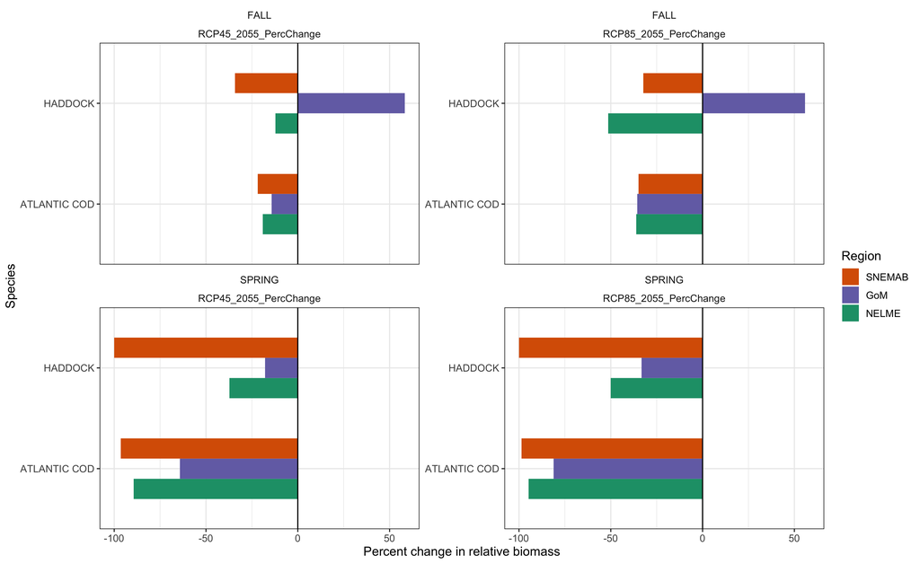

Figure: Example of average percent change across the Northeast U.S. Large Marine Ecosystem, Gulf of Maine and Southern New England/Mid-Atlantic Bight

```r
knitr::include_graphics(here::here("scratch/aja/temp_results", "perc_change_example.png"))
```

#### Summarizing differences at coastal communities

A key component to the COCA I project (and a likely reason why it was funded), was that we proposed to “localize” these regional changes down to coastal communities. To do this, we used vessel trip reports to generate “fishing footprints” for coastal communities by gear type. These fishing footprints represent locations where a vessel reported their location and catch as required by federal law. The vessel then could have gone on to fish/record other locations, eventually ending with a record of where the catch was off-loaded. Using the combination of the fished locations and the port of off-load, we created the fishing footprints.

**Vessel Trip Reports (VTR) Fishing Footprints** I am going to pick up this process with the footprints already processed. The creation of these footprints was done by someone else previously in the lab and the associated code can be seen at “Box/Mills Lab/Projects/COCA15_ClimVuln/Justin/”. Of particular interest would be the “fishing footprint by year.R” code. Also, this section is going to be a bit more “code-y” than the other sections where I tried to make some attempt to use functions. This is for a couple of reasons, but the biggest is that it seems like the code/script style will be easier for people to follow.

```r
#####
## Reading in footprints and some naming clean up
#####
# Bring in fishing footprints. These are hosted on shared folder, unfortunately.
foots_path<- "/Volumes/Shared/Research/COCA-conf/VTR fishing footprints by community and gear type 2011-2015.rds"
all_foot_dat<- readRDS(foots_path)
comm_names<- all_foot_dat$JGS.COMMUNITY
names(all_foot_dat)

# Going to work with the NOAA safe footprints, and regardless of which, want to add in a community name - cost ID name, where the cost ID is going to eventually be related to gear types
foot_safe<- TRUE
if(foot_safe){
  foot_dat<- all_foot_dat$JGS.NOAA.SAFE.COMMUNITY.GEAR.FOOTPRINTS
  names(foot_dat)<- paste(comm_names, all_foot_dat$COST_ID, sep = "_")
} else {
  foot_dat<- all_foot_dat$JGS.COMMUNITY.GEAR.FOOTPRINTS
  names(foot_dat)<- paste(comm_names, all_foot_dat$COST_ID, sep = "_")
}

# Want to add in gear type to the "name"
gear_types<- all_foot_dat$COST_ID

# Renaming -- better way to do this now I'm sure with tidyversing
gear_types<- ifelse(gear_types == 1, "Dredge",
                    ifelse(gear_types == 2, "Gillnet",
                           ifelse(gear_types == 3, "Longline",
                                  ifelse(gear_types == 4, "Pot/Trap",
                                         ifelse(gear_types == 5, "Purse/Seine",
                                                ifelse(gear_types == 6, "Trawl", "Other"))))))
comm_foot_names<- paste(comm_names, gear_types, sep = "-")
names(foot_dat)<- comm_foot_names

#####
## Pulling out the information we want for each of the footprints
#####
# The foot_dat object is a somewhat complicated list of lists. Check out the str of one of these to see (str(foot_dat[[476]])). Within that list, we can either look at the amount of kept catch at each grid cell (the second element of each list) or the proportion of catch kept at each grid cell relative to the total (the third element of each list). Going to go forward with that third component...

# Get proportion layer we want for each community-gear type.
foots_rast<- unlist(lapply(foot_dat, "[", 3))
foots_stack<- raster::stack(foots_rast) # 476 layers

#####
## Creating some additional footprints: an all gear one
#####
###
# All gear types
# For every community, we also want to have an "all gear" option, which would represent all unique cells fished across gears by vessels that landed catch at a specific community.
names_base<- names(foots_stack)
rast_ind<- nlayers(foots_stack)

# More naming nightmares..
if(foot_safe){
  comms_only<- str_replace_all(names(foots_stack), c(".Pot.Trap.JGS.SAFE.PROPORTION" = "", ".Other.JGS.SAFE.PROPORTION" = "", ".Gillnet.JGS.SAFE.PROPORTION" = "", ".Trawl.JGS.SAFE.PROPORTION" = "", ".Dredge.JGS.SAFE.PROPORTION" = "", ".Purse.Seine.JGS.SAFE.PROPORTION" = "", ".Longline.JGS.SAFE.PROPORTION" = ""))
} else {
  comms_only<- str_replace_all(names(foots_stack), c(".Pot.Trap.JGS.PROPORTION" = "", ".Other.JGS.PROPORTION" = "", ".Gillnet.JGS.PROPORTION" = "", ".Trawl.JGS.PROPORTION" = "", ".Dredge.JGS.PROPORTION" = "", ".Purse.Seine.JGS.PROPORTION" = "", ".Longline.JGS.PROPORTION" = ""))
}

comms_unique<- unique(comms_only) # 126 ports

all_stack<- stack()

for(i in seq_along(comms_unique)){
  comm_use<- comms_unique[i]
  comm_foot_ind<- which(grepl(comm_use, names(foots_stack)), arr.ind = T)
  stack_use<- foots_stack[[comm_foot_ind]]
  if(nlayers(stack_use) == 1){
    # If just one footprint for that community (e.g., one gear type), then can just store that as that is also the "all gear" footprint
    all_gear_out<- stack_use[[1]]
  } else {
    # If more than one footprint for that community (e.g., multiple gear types), we can take the sum and that should then allow us to identify any fished cells for that community
    all_gear_out<- calc(stack_use, sum, na.rm = T)
  }

  # Add it to our stack of all gear community footprints
  all_stack<- raster::stack(all_stack, all_gear_out)

  # Print loop iteration incase there is an issue
  print(paste("Iteration", i, "is done", sep = " "))
}

# Add the "all gear" footprints to the gear specific ones
if(foot_safe){
  names_all<- c(names_base, paste(comms_unique, ".All.JGS.SAFE.PROPORTION", sep = ""))
} else {
  names_all<- c(names_base, paste(comms_unique, ".All.JGS.PROPORTION", sep = ""))
}

# Check it before overwriting the "foots_stack" object
check_stack<- raster::stack(foots_stack, all_stack)
names(check_stack)<- names_all
print(check_stack)

# All looks good, overwrite it
foots_stack<- check_stack
```

**Calculating “availability” within community fishing footprints** With the footprints cleaned up a bit, we can now think about overlaying these footprints with out model projections to localize the shelf-wide results to coastal communities. To start, we will need a new function. It would be nice to use something like the `shp_over_pts_func` function, but right now, that is limited to using shapefiles. Here, the fishing footprints are stored as raster layers. So, that won’t work and we need something different.

```r
# Create the function
fish_avail_func<- function(dat) {

  if(FALSE){
    dat = mod_res$Proj_Baseline_Biomass[[1]]
  }

  # Convert data frame to sf and then a raster, with same resolution as the footprints
  dat_sf<- dat %>%
    st_as_sf(., coords = c("x", "y"), crs = 4326, remove = FALSE)
  dat_rast<- rasterize(dat_sf, foots_stack[[1]], field = "Pred", fun = mean, na.rm = TRUE)
  dat_rast<- raster::resample(dat_rast, foots_stack[[1]])

  # Create a storage vector for the mean and the SD for each of the footprints in foots_stack
  mean_out<- vector(length = raster::nlayers(foots_stack), mode = "double")
  mean_out[]<- NA
  sd_out<- vector(length = raster::nlayers(foots_stack), mode = "double")
  sd_out[]<- NA

  # Loop through each footprint, and then summarize the projected values within the footprint
  for(i in 1:raster::nlayers(foots_stack)) {

    # Specific layer we will be working with
    lay_use<- foots_stack[[i]]

    # If no data for that footprint, then mean and sd will be NA
    if(all(is.na(values(lay_use))) | cellStats(lay_use, sum, na.rm = TRUE) == 0){
      mean_out[i]<- NA
      sd_out[i]<- NA
    } else {
      # If there is data, just turn the fishing kept proportion information into binary 0/1, which will signal the cells to keep of the projection data
      m<- c(0, Inf, 1,  -Inf, 0, 0)
      rclmat<- matrix(m, ncol = 3, byrow = TRUE)
      lay_bin<- raster::reclassify(lay_use, rclmat)

      # Get coordinates of footprint cells that were fished and convert them to sf for extraction
      foot_coords<- data.frame(rasterToPoints(lay_bin, function(x) x == 1)) %>%
        st_as_sf(., coords = c("x", "y"), crs = 4326, remove = FALSE)

      # Okay, now get the projected values at those points and then the proportion of catch at each to use as the weights.
      proj_vals<- raster::extract(dat_rast, foot_coords)

      # Mean and SD
      if(all(is.na(proj_vals))) {
        mean_out[i]<- NA
        sd_out[i]<- NA
      } else {
        if(length(proj_vals) == 1){
          # Can't get SD with one value
          mean_out[i]<- mean(proj_vals, na.rm = T)
          sd_out[i]<- NA
        } else {
          mean_out[i]<- mean(proj_vals, na.rm = T)
          sd_out[i]<- sd(proj_vals, na.rm = T)
        }
      }
    }
  }

  # Create a data frame with each community footprint name, and then the resulting mean SD of projected values
  out_df<- data.frame("Community_Footprint" = names(foots_stack), "Mean_Avail" = mean_out, "SD_Avail" = sd_out)
  return(out_df)
}

# Now map it to mod_res and the specific columns we are interested in...
cols_keep<- c("COMNAME", "SEASON", "Proj_Baseline_Biomass", "RCP45_2055_Mu_Biomass", "RCP85_2055_Mu_Biomass")
foot_res<- mod_res %>%
  select(., one_of(cols_keep)) %>%
  mutate(., "Baseline_Comm_Avail" = map(Proj_Baseline_Biomass, fish_avail_func),
         "RCP45_2055_Comm_Avail" = map(RCP45_2055_Mu_Biomass, fish_avail_func),
         "RCP85_2055_Comm_Avail" = map(RCP85_2055_Mu_Biomass, fish_avail_func))

# What did that just do?? For each species-season-community-footprint, we now have the mean and SD projected values
summary(foot_res$RCP45_2055_Comm_Avail[[1]])
```

**Calculating changes in “availability” within community fishing footprints** Alright, the final step is using the average projected values (baseline and under future potential conditions from the climate scenarios/ensemble statistic/time horizons) to get a percentage change in availability. Like before, we will write a function to do this and then map the function to the associated columns of our “foot_res” dataframe.

```r
# A change function, dealing with some of the subtleties for how the data are stored within the "foot_res" piece...
avail_change_func<- function(baseline, projected, scale){
  if(FALSE){
    baseline = foot_res$Baseline_Comm_Avail[[1]]
    projected = foot_res$RCP45_2055_Comm_Avail[[1]]
    scale = "percent"
  }

  avail_change_out<- data.frame("Community_Footprint" = baseline$Community_Footprint)

  if(scale == "raw"){
    avail_change_out$Change<- projected$Mean_Avail - baseline$Mean_Avail
    return(avail_change_out)
  } else {
    avail_change_out$Change<- 100*((projected$Mean_Avail - baseline$Mean_Avail)/baseline$Mean_Avail)
    return(avail_change_out)
  }
}

# Map it...
foot_res<- foot_res %>%
  mutate(., "Comm_RCP45_2055_PercChange" = pmap(list(baseline = Baseline_Comm_Avail, projected = RCP45_2055_Comm_Avail, scale = list("percent")), avail_change_func),
        "Comm_RCP85_2055_PercChange" = pmap(list(baseline = Baseline_Comm_Avail, projected = RCP85_2055_Comm_Avail, scale = list("percent")), avail_change_func))

# Look at it...
summary(foot_res$Comm_RCP45_2055_PercChange[[1]])
```

## Where to go from here?

Hopefully this has laid out our workflow for the COCA I project in a way that is at least *somewhat* easy to follow and understand. More importantly, I hope it has also highlighted areas where I think we can improve things – and I am sure there are areas that I have overlooked that might jump out to you, too! Overall, it is great that we have something that “works”, but I am excited to work together to make this workflow even more efficient and robust.

A work by [Andrew Allyn](https://github.com/aallyn/)

*aallyn@gmri.org*